# R Notebook

در زیر می‌توانیم درباره‌ی مقادیر ستون‌های مختلف اطلاعاتی درباره نوع آن‌ها و اطلاعات کمی درباره توزیع آن‌ها به دست آوریم.

```r
df = read.csv("lyon_housing.csv")
str(df)
```

```
'data.frame':   40516 obs. of  14 variables:
 $ date_transaction        : chr  "19/10/31" "18/11/26" "16/08/04" "16/11/18" ...
 $ type_purchase           : chr  "ancien" "ancien" "ancien" "ancien" ...
 $ type_property           : chr  "maison" "maison" "appartement" "appartement" ...
 $ rooms_count             : int  5 2 1 3 1 2 1 4 1 2 ...
 $ surface_housing         : int  100 52 28 67 28 42 28 84 28 42 ...
 $ surface_effective_usable: num  NA NA 28.2 66.3 NA ...
 $ surface_terrain         : int  247 156 0 0 0 0 0 0 0 0 ...
 $ parkings_count          : int  0 0 1 1 1 1 1 1 1 1 ...
 $ price                   : num  530000 328550 42500 180900 97000 ...
 $ address                 : chr  "6 PAS DES ANTONINS" "12 RUE DU LUIZET" "4 RUE DE L ESPOIR" "6 RUE DE L ESPOIR" ...
 $ district                : chr  "Villeurbanne" "Villeurbanne" "Villeurbanne" "Villeurbanne" ...
 $ latitude                : num  45.8 45.8 45.8 45.8 45.8 ...
 $ longitude               : num  4.88 4.88 4.88 4.88 4.88 ...
 $ date_construction       : chr  "03/06/11 11:38" "03/06/11 11:38" "03/06/11 11:38" "03/06/11 11:38" ...
```

```r
summary(df)
```

```
 date_transaction   type_purchase      type_property       rooms_count
 Length:40516       Length:40516       Length:40516       Min.   :1.000
 Class :character   Class :character   Class :character   1st Qu.:2.000
 Mode  :character   Mode  :character   Mode  :character   Median :3.000
                                                          Mean   :2.792
                                                          3rd Qu.:4.000
                                                          Max.   :6.000

 surface_housing  surface_effective_usable surface_terrain
 Min.   : 20.00   Min.   :  2.81           Min.   :  0.000
 1st Qu.: 45.00   1st Qu.: 44.70           1st Qu.:  0.000
 Median : 63.00   Median : 62.80           Median :  0.000
 Mean   : 65.24   Mean   : 63.53           Mean   :  3.765
 3rd Qu.: 80.00   3rd Qu.: 78.11           3rd Qu.:  0.000
 Max.   :300.00   Max.   :270.67           Max.   :944.000
                  NA's   :14491
 parkings_count       price           address            district
 Min.   :0.0000   Min.   :  24000   Length:40516       Length:40516
 1st Qu.:0.0000   1st Qu.: 155273   Class :character   Class :character
 Median :1.0000   Median : 220000   Mode  :character   Mode  :character
 Mean   :0.5993   Mean   : 255759
 3rd Qu.:1.0000   3rd Qu.: 309000
 Max.   :3.0000   Max.   :2780000

    latitude       longitude     date_construction
 Min.   :45.72   Min.   :4.773   Length:40516
 1st Qu.:45.75   1st Qu.:4.831   Class :character
 Median :45.76   Median :4.854   Mode  :character
 Mean   :45.76   Mean   :4.852
 3rd Qu.:45.77   3rd Qu.:4.876
 Max.   :45.81   Max.   :4.920
 NA's   :143     NA's   :143
```

```r
#View(df)
```

```r
head(df, 10)
```

|  | date_transaction | type_purchase | type_property | rooms_count | surface_housing | surface_effective_usable | surface_terrain | parkings_count | price | address | district | latitude | longitude | date_construction |
| --- | --- | --- | --- | --- | --- | --- | --- | --- | --- | --- | --- | --- | --- | --- |
| 1 | 19/10/31 | ancien | maison | 5 | 100 | NA | 247 | 0 | 530000 | 6 PAS DES ANTONINS | Villeurbanne | 45.78167 | 4.879333 | 03/06/11 11:38 |
| 2 | 18/11/26 | ancien | maison | 2 | 52 | NA | 156 | 0 | 328550 | 12 RUE DU LUIZET | Villeurbanne | 45.78324 | 4.884683 | 03/06/11 11:38 |
| 3 | 16/08/04 | ancien | appartement | 1 | 28 | 28.20 | 0 | 1 | 42500 | 4 RUE DE L ESPOIR | Villeurbanne | 45.78149 | 4.883474 | 03/06/11 11:38 |
| 4 | 16/11/18 | ancien | appartement | 3 | 67 | 66.30 | 0 | 1 | 180900 | 6 RUE DE L ESPOIR | Villeurbanne | 45.78149 | 4.883474 | 03/06/11 11:38 |
| 5 | 16/12/16 | ancien | appartement | 1 | 28 | NA | 0 | 1 | 97000 | 163 AV ROGER SALENGRO | Villeurbanne | 45.78149 | 4.883474 | 03/06/11 11:38 |
| 6 | 17/01/06 | ancien | appartement | 2 | 42 | NA | 0 | 1 | 112000 | 163 AV ROGER SALENGRO | Villeurbanne | 45.78149 | 4.883474 | 03/06/11 11:38 |
| 7 | 17/02/01 | ancien | appartement | 1 | 28 | NA | 0 | 1 | 93000 | 4 RUE DE L ESPOIR | Villeurbanne | 45.78149 | 4.883474 | 03/06/11 11:38 |
| 8 | 17/02/27 | ancien | appartement | 4 | 84 | 83.60 | 0 | 1 | 152000 | 34 RUE DU LUIZET | Villeurbanne | 45.78149 | 4.883474 | 03/06/11 11:38 |
| 9 | 17/02/22 | ancien | appartement | 1 | 28 | 28.30 | 0 | 1 | 83000 | 4 RUE DE L ESPOIR | Villeurbanne | 45.78149 | 4.883474 | 03/06/11 11:38 |
| 10 | 17/03/07 | ancien | appartement | 2 | 42 | 42.01 | 0 | 1 | 115400 | 163 AV ROGER SALENGRO | Villeurbanne | 45.78149 | 4.883474 | 03/06/11 11:38 |

با توجه به نمودارهای زیر، مناطق تفاوت بسیار فاحشی از لحاظ قیمت با یکدیگر ندارند و همچنین خانه با بالاترین قیمت مربوط به منطقه‌ی Villeurbanne است.

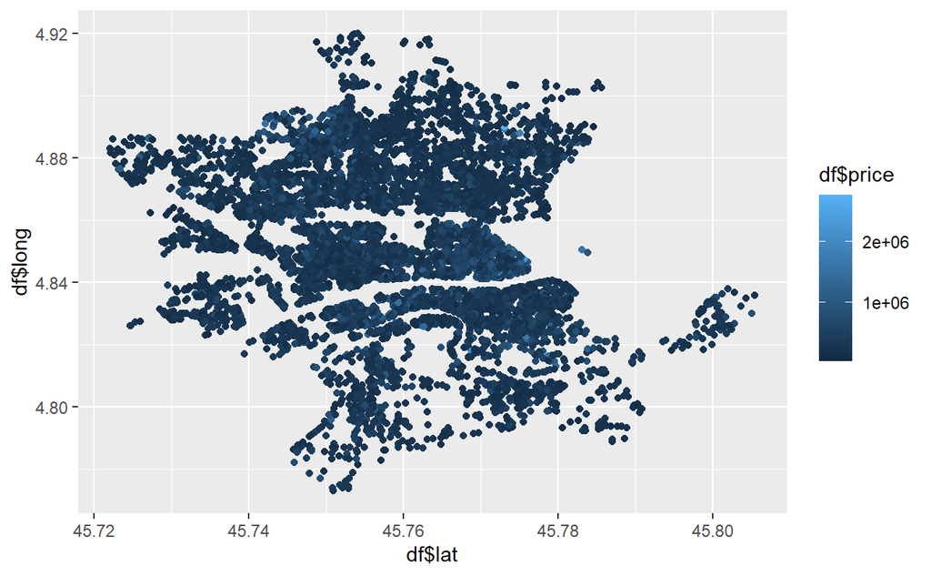

```r
library(ggplot2)
ggplot(df, aes(x=df$lat, y=df$long)) +
geom_point(aes(col = df$price))
```

می‌توانیم مناطق مختلف و قرارگیری اون‌ها رو در شکل ببینیم.

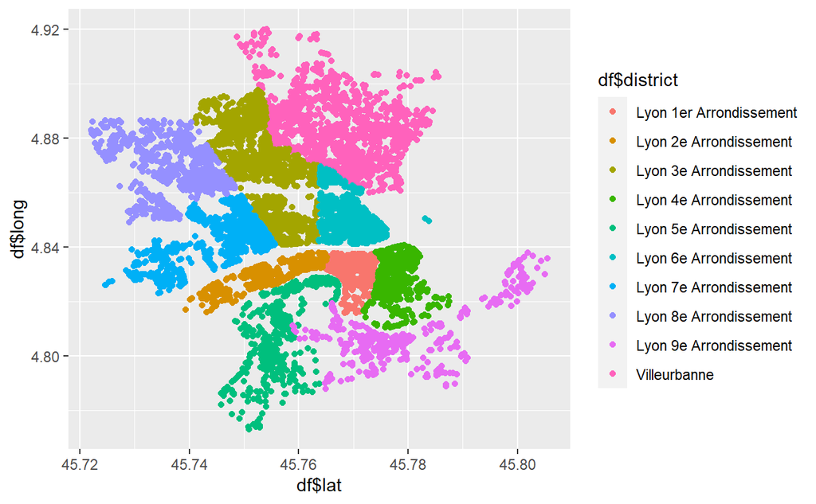

```r
library(ggplot2)
ggplot(df, aes(x=df$lat, y=df$long)) +
geom_point(aes(col = df$district))
```

تعداد داده‌های مخدوش را محاسبه میکنیم. برای ستون surface_effective_usabel داده‌ی از دست رفته‌ی زیادی داریم و میتوانیم این ستون را از دیتاسیت حذف کنیم. برای ستون‌های latitude و longitude تعداد داده‌های مخدوش کمتر است اما جای آن‌ها مقادیری قرار نمیدهیم و در محاسابت بعدی این خانه‌ها را به صورت جدا حذف می‌کنیم یعنی در محاسابت به دلیل NA بودن آن‌ها را لحاظ نمیکنیم.

```r
colSums(is.na(df))
```

```
        date_transaction            type_purchase            type_property
                       0                        0                        0
             rooms_count          surface_housing surface_effective_usable
                       0                        0                    14491
         surface_terrain           parkings_count                    price
                       0                        0                        0
                 address                 district                 latitude
                       0                        0                      143
               longitude        date_construction
                     143                        0
```

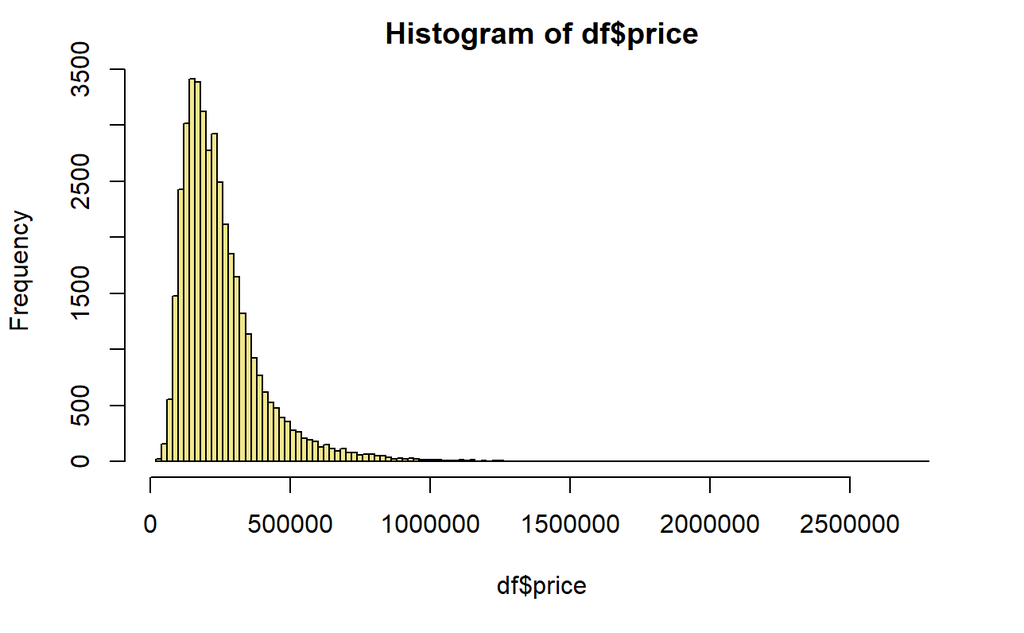

```r
hist(df$price,breaks=100, col = 'khaki')
```

در شکل زیر می‌توانیم میانگین قیمت را طی سال‌های مختلف مشاهده کنیم. مشخص است که قیمت خانه‌ها در طی سال سیر صعودی داشته است. که قابل انتظار است و می‌تواند دلایل متعددی از جمله تورم داشته باشد.

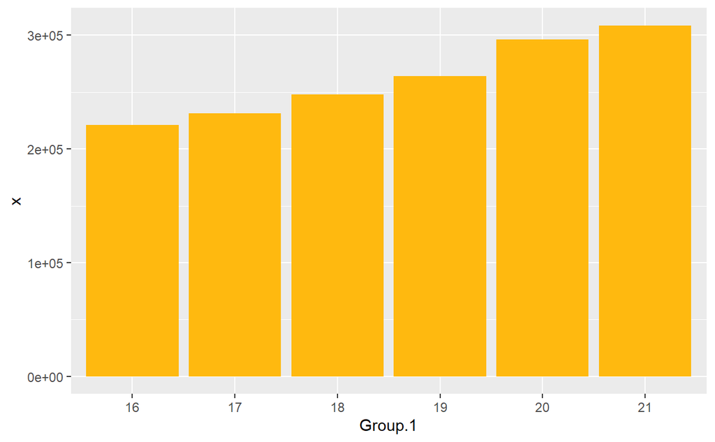

```r
yr <- substr(df$date_transaction, 1, 2)
year_df = data.frame(yr, df$price)
mean = aggregate(year_df$df.price, list(year_df$yr), mean)
gg = ggplot(mean, aes(x=Group.1, y=x)) +
geom_bar(stat = "identity", fill = 'darkgoldenrod1')
gg
```

با توجه به نمودار زیر می‌توان دید که تعداد فروش خانه‌ها هم در طی این سال‌ها روند کاهشی داشته است. می‌تواند علت آن کاهش توان خرید در اثر افزایش تورم باشد.

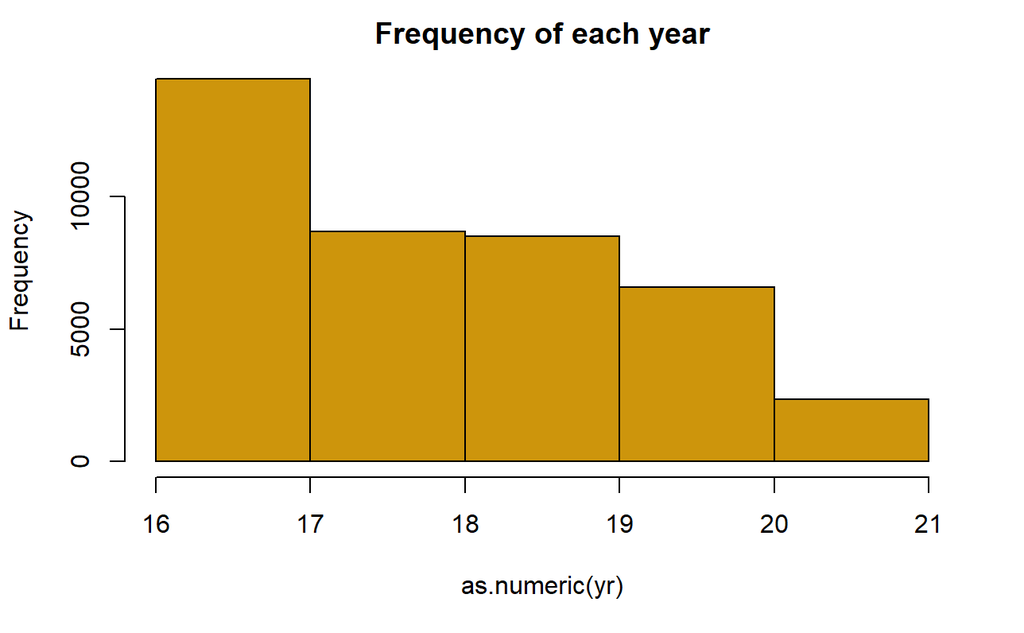

```r
yr <- substr(df$date_transaction, 1, 2)
hist(as.numeric(yr), breaks = 6, col = 'darkgoldenrod3', main = "Frequency of each year")
```

در نمودار زیر می‌توان مشاهده کرد که میانگین قیمت خانه در ماه‌های مختلف تفاوت چندانی ندارد و تقریبا ثابت است.

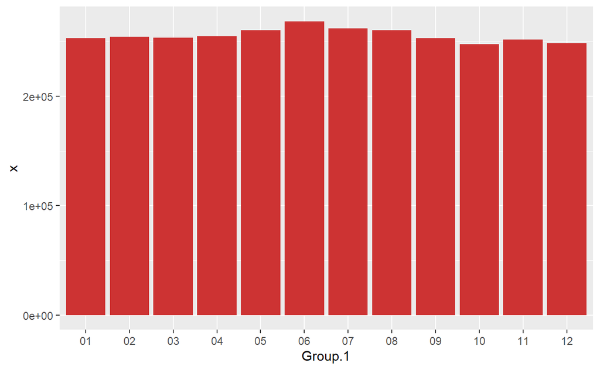

```r
month <- substr(df$date_transaction, 4, 5)
month_df = data.frame(month, df$price)
mean = aggregate(month_df$df.price, list(month_df$month), mean)
gg = ggplot(mean, aes(x=Group.1, y=x)) +
geom_bar(stat = "identity", fill = 'brown3')
gg
```

با توجه به نمودار به جز ماه اول سال بیشترین فروش تقریبا مربوط به وسط سال است. با توجه به مقاله Zillow در میانه سال به دلیل “buyer-desparation” فروشنده‌ها ممکن است با قیمت‌های محتلف توافق کنند و این میزان فروش خانه‌ها را افزایش می‌دهد.

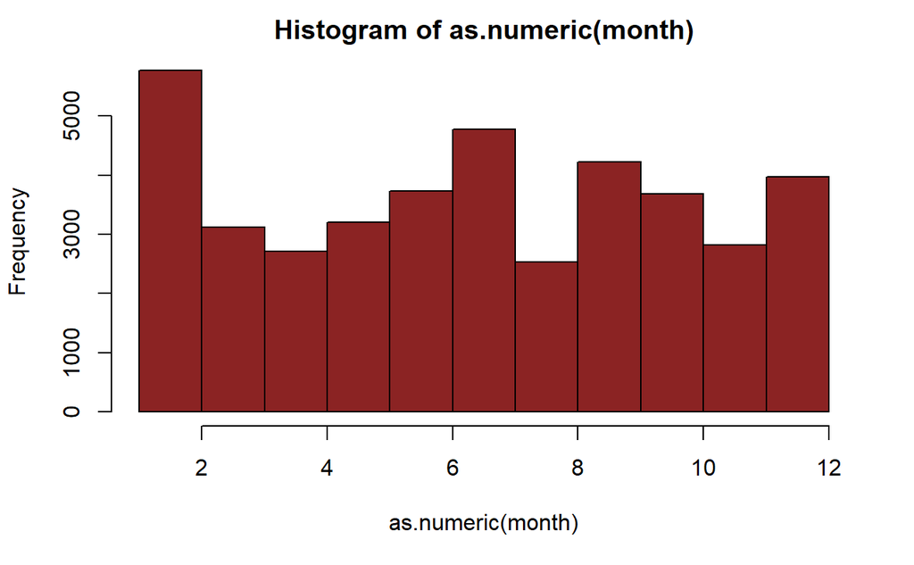

```r
month <- substr(df$date_transaction, 4, 5)
hist(as.numeric(month), breaks = 12, col = 'brown4')
```

```r
coordinates = df[c(12, 13)]
df = df[-c(6, 12, 13)]
```

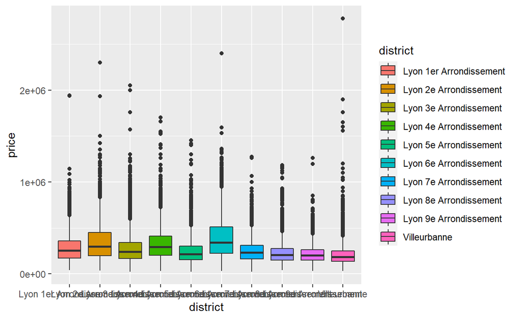

```r
library(ggplot2)
ggplot(df, aes(x=district, y=price, fill=district))+
  geom_boxplot()
```

همانطور که قابل پیش‌بینی‌ست قیمت خانه‌های maison از appartementsبیشتر است و قیمت آپارتمان‌ها به گونه‌ای است که نصف آن‌ها در رنج کمتری حول میانه قرار می‌؛یرند و متراکم‌تر هستند اما در تو نوع خانه دارای outlier هستند.

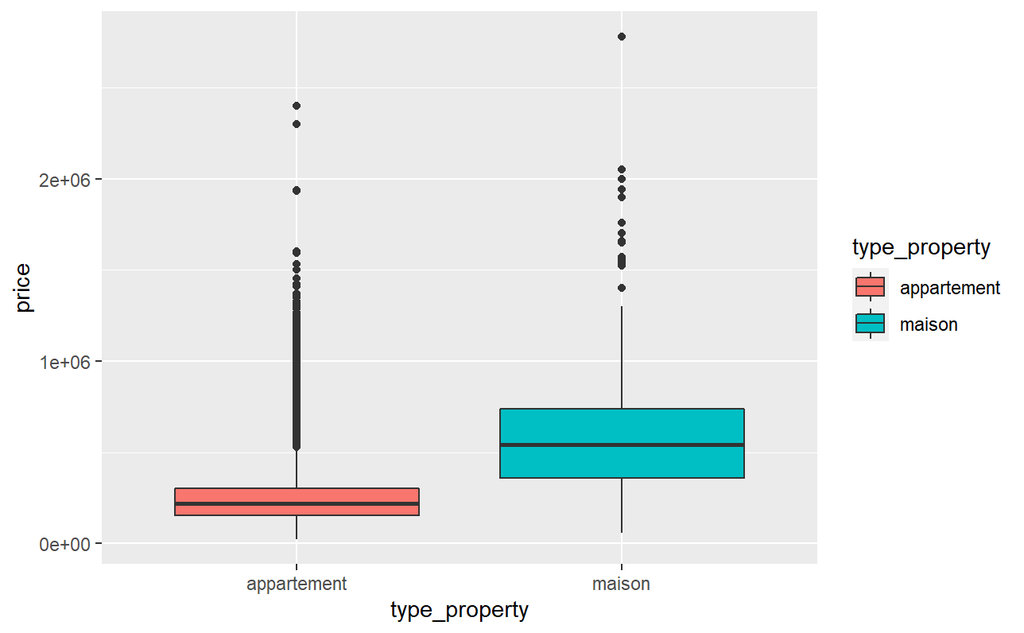

```r
ggplot(df, aes(x=type_property, y=price, fill=type_property))+
  geom_boxplot()
```

میخواهیم مدل رگرسیونی بسازیم و حال بین ستون‌های مختلف میزان کوریلیشن آن را با قیمت میسنجیم. در صورت داشتن کوریلیشن آن را در مدل استفاده می‌کنیم در غیر این صورت آن را از مدل حذف میکنیم. با توجه به شکل اول به نظر می‌رسد قیمت با تعداد اتاق‌ها و مساحت خانه کوریلیشن زیادی داشته باشد. در شکل زیر برای ستون‌های numeric نمودار‌ها دو به دو رسم کرده‌ایم. همانطور که مشخص است بعضی داده‌ها با هم کوریلیشن مشخص‌تری دارند. در ادامه به طور دقیقا تر این نمودارها را بررسی میکنیم.

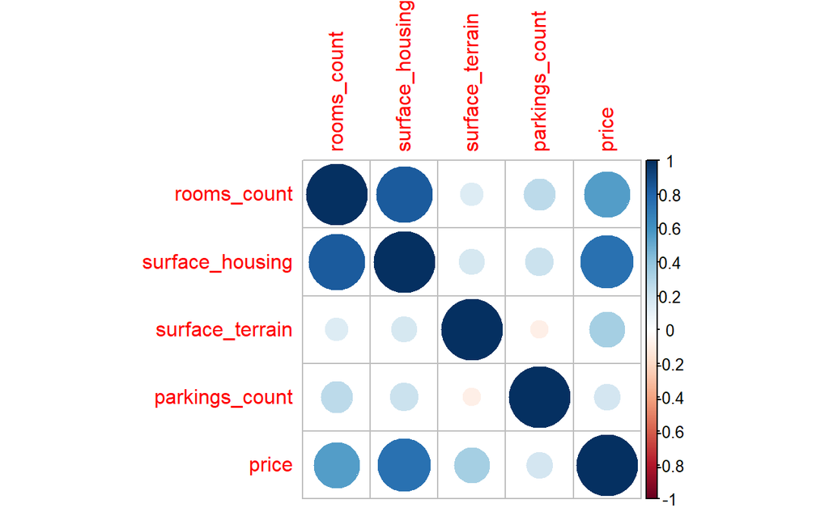

```r
library(corrplot)
sub_df = df[c(4, 5, 6, 7, 8)]
cor.table = cor(sub_df)
corrplot(cor.table)
```

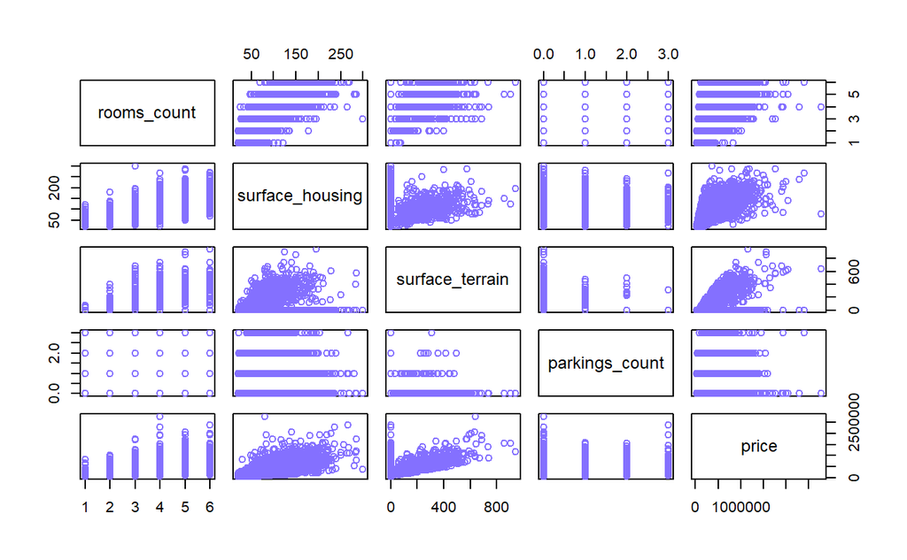

```r
pairs(sub_df, col = 'lightslateblue')
```

در شکل زیر نمودار قیمت و تعداد اتاق‌ها را مشاهده میکنیم. مشخص است با افزایش تعداد اتاق‌ها قیمت خانه افزایش پیدا می‌کند. در تعداد اتاق‌های بیشتر outlier کمتری داریم . همچنین می‌توان با آنالیز واریانس مقدار p value را محاسبه کرد و آزمون زیر را انجام داد: فرض صفر: هیچ کوریلیشنی بین تعداد اتاق‌ها و قیمت وجود ندارد. فرض یک: بین قیمت و تعداد اتاق‌ها کوریلیشن وجود دارد. با توجه به اینکه مقدار p value از ۰.۰۵ کمتر است می‌توان فرض h0 را رد کرد. در نتیجه بین تعداد اتاق‌ها و قیمت کوریلیشن وجود دارد.

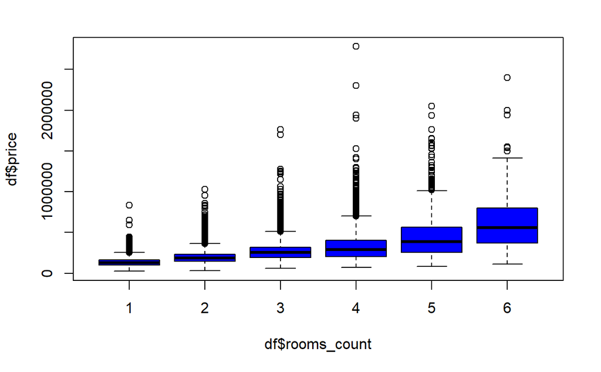

```r
boxplot(df$price~df$rooms_count, col = 'blue')
```

```r
anlysis = aov(price~rooms_count, data=df)
summary(anlysis)
```

```
               Df    Sum Sq   Mean Sq F value Pr(>F)
rooms_count     1 2.999e+14 2.999e+14   18209 <2e-16 ***
Residuals   40514 6.672e+14 1.647e+10
---
Signif. codes:  0 ‘***’ 0.001 ‘**’ 0.01 ‘*’ 0.05 ‘.’ 0.1 ‘ ’ 1
```

نمودار قیمت و مساخت خانه رسم شده است. می‌توان مطابق بخش قبل آزمون تیت کوریلیشن انجام داد. با توجه به نتیجه میزان کوریلیشن نزدیک به ۰.۷۵ است. با توجه به آن بین این دو مقدار کوریلیشن وجود دارد در نتیجه مساحت خانه را در مدل وارد میکنیم.

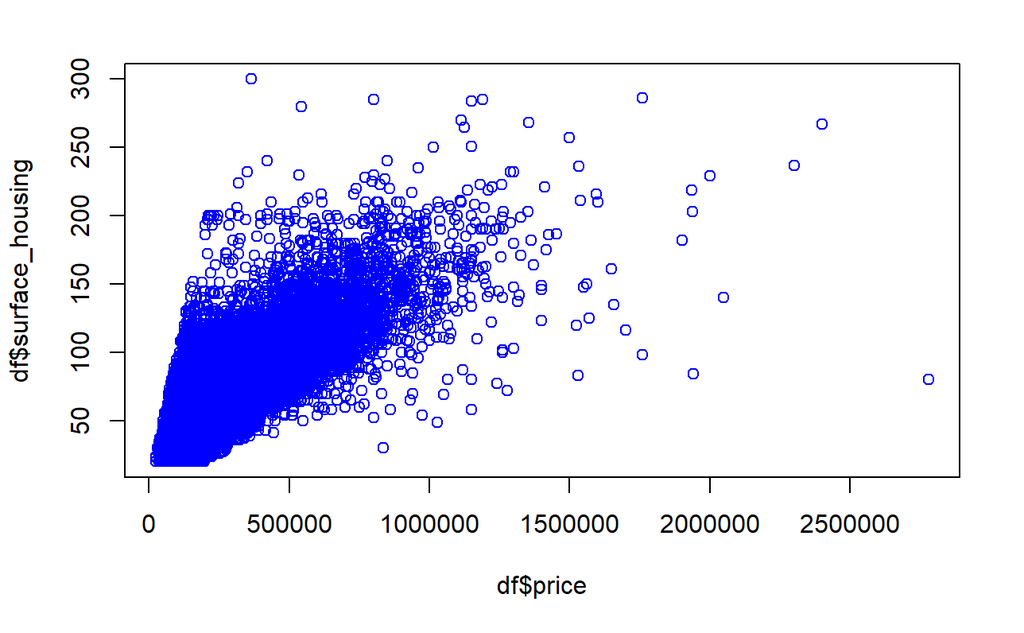

```r
plot(df$price,df$surface_housing, col = 'blue')
```

```r
cor.test(~price+surface_housing,data=df)
```

```
    Pearson's product-moment correlation

data:  price and surface_housing
t = 226.07, df = 40514, p-value < 2.2e-16
alternative hypothesis: true correlation is not equal to 0
95 percent confidence interval:
 0.7425292 0.7511411
sample estimates:
      cor
0.7468664
```

نمودار قیمت و تعداد پارکینگ‌ها را رسم کرده‌ایم. مطابق بخش‌های قبل میتوانیم آنالیز واریانس انجام دهیم. با توجه به نتیجه فرض صفر را یعنی عدم وجود کوریلیشن را رد میکنیم. در نتیجه بین قیمت خانه و تعداد پارکینگ کوریلیشن وجود دارد و میتوانیم این ستون را در مدل استفاده کنیم.

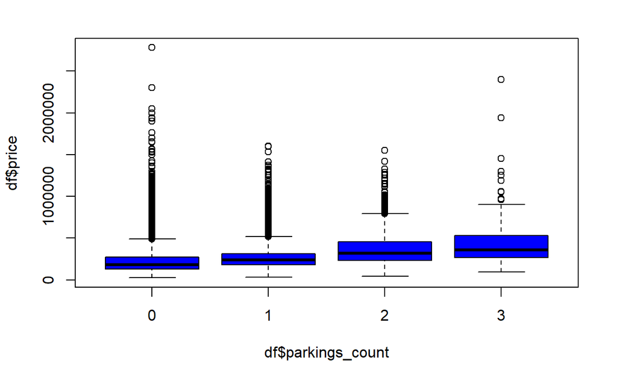

```r
boxplot(df$price~df$parkings_count, col = 'blue')
```

```r
anlysis = aov(price~parkings_count, data=df)
summary(anlysis)
```

```
                  Df    Sum Sq   Mean Sq F value Pr(>F)
parkings_count     1 3.396e+13 3.396e+13    1474 <2e-16 ***
Residuals      40514 9.331e+14 2.303e+10
---
Signif. codes:  0 ‘***’ 0.001 ‘**’ 0.01 ‘*’ 0.05 ‘.’ 0.1 ‘ ’ 1
```

نمودار قیمت خانه و surface_terrian رسم شده است. آزمون کوریلیشن انجام میدهیم. مقدار کوریلیشن به دست آمده ۰.۳ است. با توجه به اینکه مقدار کوریلیشن کم است از این ستون برای پیش بینی قیمت استفاده نمیکنیم و آن را از مدل حذف میکنیم.

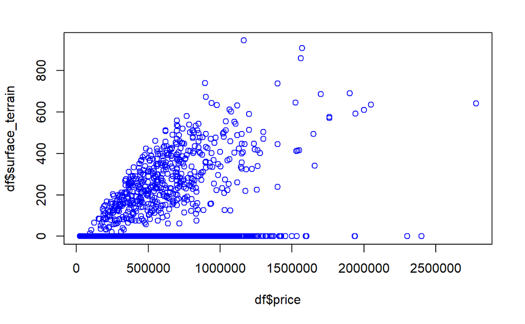

```r
plot(df$price,df$surface_terrain, col = 'blue')
```

```r
cor.test(~price+surface_terrain,data=df)
```

```
    Pearson's product-moment correlation

data:  price and surface_terrain
t = 71.84, df = 40514, p-value < 2.2e-16
alternative hypothesis: true correlation is not equal to 0
95 percent confidence interval:
 0.3274816 0.3447558
sample estimates:
     cor
0.336147
```

و در نهایت با استفاده از ستون‌های انتخاب شده که با قیمت کوریلیشن داشتند مدل خطی خود را میسازیم. هیستوگرام حاصل توزیع نزدیک به نرمال دارد که این نتیجه اهمیت دارد زیرا نشان می‌دهد مدل ماانتظار می‌رود با توجه به نرمال بودن ارورها خوب کار کند و فرض‌هایی که در ساخت مدل کرده‌ایم درست باشند.

```r
model = lm(df$price~df$rooms_count+df$surface_housing+df$parkings_count)
summary(model)
```

```
Call:
lm(formula = df$price ~ df$rooms_count + df$surface_housing +
    df$parkings_count)

Residuals:
     Min       1Q   Median       3Q      Max
-1090904   -55681    -4220    48235  2494354

Coefficients:
                   Estimate Std. Error t value Pr(>|t|)
(Intercept)          1754.9     1332.4   1.317    0.188
df$rooms_count     -32345.3      786.7 -41.116   <2e-16 ***
df$surface_housing   5165.9       32.5 158.958   <2e-16 ***
df$parkings_count   12177.9      861.9  14.129   <2e-16 ***
---
Signif. codes:  0 ‘***’ 0.001 ‘**’ 0.01 ‘*’ 0.05 ‘.’ 0.1 ‘ ’ 1

Residual standard error: 100600 on 40512 degrees of freedom
Multiple R-squared:  0.5761,    Adjusted R-squared:  0.5761
F-statistic: 1.836e+04 on 3 and 40512 DF,  p-value: < 2.2e-16
```

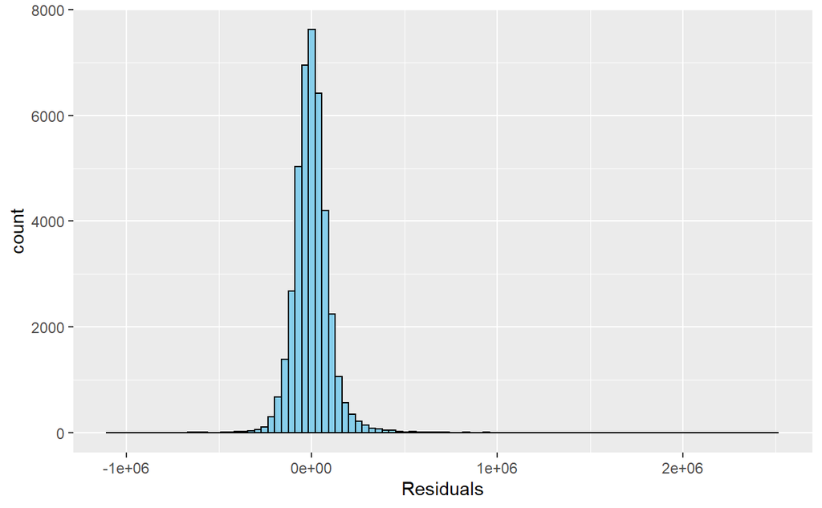

```r
residuals <- data.frame('Residuals' = model$residuals)
res_hist <- ggplot(residuals, aes(x=Residuals)) + geom_histogram(color='black', fill='skyblue', bins = 100)
res_hist
```

```r
library("rjson")
stations <- fromJSON(file = "station_coordinates.json")
count = 0
for (l in stations) {
  count = count + lengths(l[1])
}
count
```

```
stations
     174
```

```r
mat = matrix(0, nrow=count, ncol=3)
row = 1
for (s in stations) {
  for (l in s[1]) {
    for (variable in l) {
      mat[row, 1] = variable
      row = row + 1
    }
  }
}
row = 1
for (s in stations) {
  for (l in s[2]) {
    for (variable in l) {
      mat[row, 2] = variable
      row = row + 1
    }
  }
}
row = 1
for (s in stations) {
  for (l in s[3]) {
    for (variable in l) {
      mat[row, 3] = variable
      row = row + 1
    }
  }
}
stations = data.frame(mat)
```

```r
library(dplyr)
stations = distinct(stations)
```

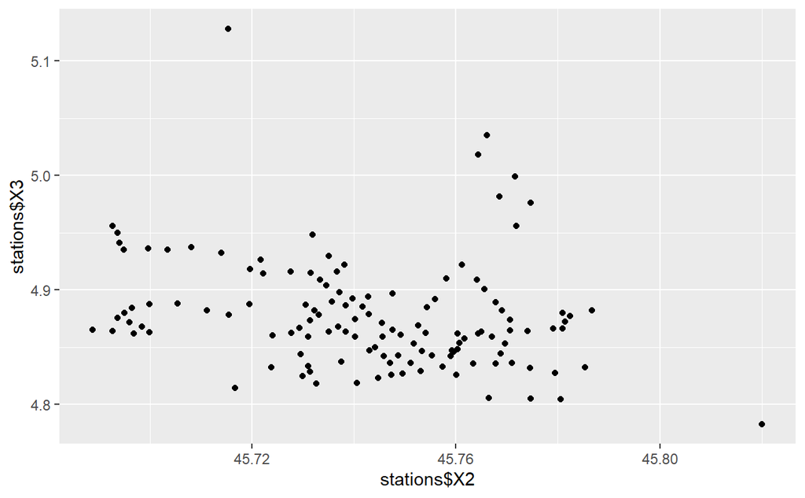

```r
stations$X2 <- as.numeric(stations$X2)
stations$X3 <- as.numeric(stations$X3)
coordinates$latitude <- as.numeric(coordinates$latitude)
coordinates$longitude <- as.numeric(coordinates$longitude)

ggplot(stations, aes(x=stations$X2, y=stations$X3)) +
geom_point()
```

```r
library("geosphere")
min_dist = vector()

for (i in 1:length(coordinates$latitude)) {
  house = c(coordinates[i, 2], coordinates[i, 1])
  min = 2100
  for (j in length(stations$X2)) {
    station = c(stations[j, 3], stations[j, 2])
    d = 3963.0 * acos(sin(coordinates[i, 1]) * sin(stations[j, 2])) +
      cos(coordinates[i, 1]) * cos(stations[j, 2]) * cos(coordinates[i, 2] - stations[j, 3])
    dist = d * 1.609344
    #dist = distCosine(house, station)
    if (!is.na(dist) && dist < min) {
      min = dist
    }
  }
  min_dist = c(min_dist, min)
}
```

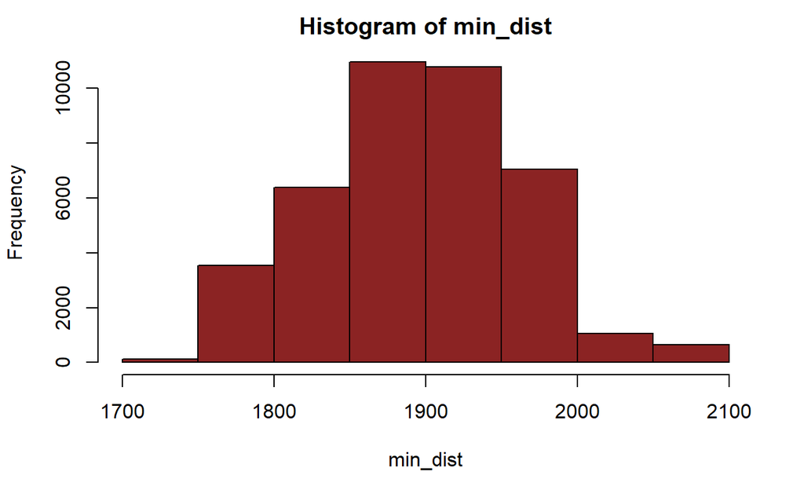

```r
hist(min_dist, breaks = 10, col = 'brown4')
```

```r
dist_to_uni = vector()

for (i in 1:length(coordinates$latitude)) {
  pt1 = c(coordinates[i, 2], coordinates[i, 1])
  pt2 = c(4.865561717882041, 45.780234113880425)
  dist = distCosine(pt1, pt2)
  dist_to_uni = c(dist_to_uni, dist)
}
dist_to_uni = dist_to_uni / max(dist_to_uni)
```

میخواهیم از بین آپارتمان‌های موجود با توجه به معیار‌ها خانه‌ای را پیدا کنیم. برای پیدا کردن بهترین خانه با توجه به معیارها تابعی از قیمت، فاصله تا دانشگاه، فاصله تا نزدیک‌ترین ایستگاه مترو، تعداد اتاق‌ها و مساخت خانه در نظر میگیریم و برای هر ستون ضریبی در نظر میگیریم. ستون‌ها را از قبل نرمال میکنیم و در نهایت از ستون آخر ایجاد شده مینیمم مقدار را در نظر میگیریم. این خانه با توجه به مهم بودن فاصله تا دانشگاه در منطقه Villeurbann قرار دارد و با توجه به اینکه معیارهای مورد نظر در هر منطقه نزدیک به هم است احتمالا همین منطقه برای خرید خانه مناسب باشد.

```r
df$type_property = as.factor(df$type_property)
data = data.frame(df$type_property, df$surface_housing, df$rooms_count, df$price, min_dist, dist_to_uni)
data = data[data$df.type_property == 'appartement',]
data = data[-c(1)]
data$df.surface_housing = -data$df.surface_housing / max(data$df.surface_housing)
data$df.rooms_count = -data$df.rooms_count / max(data$df.rooms_count)
data$df.price = data$df.price / max(data$df.price)
data$min_dist = data$min_dist / max(data$min_dist)
data$dist_to_uni = data$dist_to_uni / max(data$dist_to_uni)
data$func=10*data$df.surface_housing+5*data$df.rooms_count+10*data$df.price+5*data$min_dist+100*data$dist_to_uni
View(data$func)
index = which.min(data$func)
index
```

```
[1] 2472
```

```r
print(df[index,])
```

|  | date_transaction | type_purchase | type_property | rooms_count | surface_housing | surface_terrain | parkings_count | price | address | district | date_construction |
| --- | --- | --- | --- | --- | --- | --- | --- | --- | --- | --- | --- |
| 2472 | 20/12/29 | ancien | appartement | 3 | 57 | 0 | 1 | 245000 | 127 CRS EMILE ZOLA | Villeurbanne | 03/06/11 11:38 |

```r
NA
```